# Project 1: Wrangling, Exploration, Visualization

#### Wrangling

```r
clean_data <- full_data %>% filter(TOI.x > 200) %>% select(-c(Season.y, Position.y, GP.y, Season.x.x, Position.x.x, GP.x.x, TOI_All.x, Season.y.y, Position.y.y, GP.y.y, TOI_All.y, Take_GAR.y, Draw_GAR.y, Pens_GAR.y)) %>% rename(Season = Season.x,
            Position = Position.x,
            GP = GP.x,
            "TOI_All" = TOI.x,
            "iSh%" = "Sh%.x",
            "TOI_5V5" = TOI.y,
            "Sh%" = "Sh%.y",
            Draw_GAR = Draw_GAR.x,
            Take_GAR = Take_GAR.x,
            Pens_GAR = Pens_GAR.x)
```

With this code I am filtering out all players who played less than 200 minutes total as that is not a sufficient sample size to calculate rate stats, removing repeat columns from joins, and renaming columns to be more clearly named.

```r
clean_data %>% arrange(desc(GAR)) %>% head()
```

```
## # A tibble: 6 × 74
##   Player      Season Team  Position    GP TOI_All     G    A1    A2 Points   iSF
##   <chr>       <chr>  <chr> <chr>    <dbl>   <dbl> <dbl> <dbl> <dbl>  <dbl> <dbl>
## 1 Connor McD… 20-21  EDM   C           56   1241.    33    50    22    105   200
## 2 Jared McCa… 20-21  PIT   C           43    607.    14    12     6     32    94
## 3 Patrice Be… 20-21  BOS   C           54    983.    23    11    14     48   182
## 4 Cale Makar  20-21  COL   D           44   1070.     8    22    14     44   104
## 5 Mikko Rant… 20-21  COL   R           52   1036.    30    18    18     66   177
## 6 Auston Mat… 20-21  TOR   C           52   1121.    41    15    10     66   222
## # … with 63 more variables: iFF <dbl>, iCF <dbl>, ixG <dbl>, iSh% <dbl>,
## #   FSh% <dbl>, xFSh% <dbl>, iBLK <dbl>, GIVE <dbl>, TAKE <dbl>, iHF <dbl>,
## #   iHA <dbl>, iPENT2 <dbl>, iPEND2 <dbl>, iPENT5 <dbl>, iPEND5 <dbl>,
## #   iPEN± <dbl>, FOW <dbl>, FOL <dbl>, FO± <dbl>, TOI_5V5 <dbl>, GF% <dbl>,
## #   SF% <dbl>, FF% <dbl>, CF% <dbl>, xGF% <dbl>, GF/60 <dbl>, GA/60 <dbl>,
## #   SF/60 <dbl>, SA/60 <dbl>, FF/60 <dbl>, FA/60 <dbl>, CF/60 <dbl>,
## #   CA/60 <dbl>, xGF/60 <dbl>, xGA/60 <dbl>, G±/60 <dbl>, S±/60 <dbl>, …
```

```r
clean_data %>% group_by(Team) %>% arrange(Team, desc(GAR))
```

```
## # A tibble: 690 × 74
## # Groups:   Team [31]
##    Player     Season Team  Position    GP TOI_All     G    A1    A2 Points   iSF
##    <chr>      <chr>  <chr> <chr>    <dbl>   <dbl> <dbl> <dbl> <dbl>  <dbl> <dbl>
##  1 Troy Terry 20-21  ANA   C           48    706.     7    10     3     20    69
##  2 Cam Fowler 20-21  ANA   D           56   1219.     5     5    13     23    75
##  3 Trevor Ze… 20-21  ANA   C           24    370.     3     8     2     13    53
##  4 Adam Henr… 20-21  ANA   C           45    722.    12     6     3     21    77
##  5 Danton He… 20-21  ANA   L           43    635.     7     6     1     14    76
##  6 Kevin Sha… 20-21  ANA   D           55   1166.     2     6     7     15    93
##  7 Derek Gra… 20-21  ANA   C           46    670.     6     4     5     15    66
##  8 Max Comto… 20-21  ANA   L           55    850.    16    13     4     33    94
##  9 Jani Haka… 20-21  ANA   D           42    782.     0     1     0      1    41
## 10 Alex Volk… 20-21  ANA   R           18    250.     4     1     3      8    17
## # … with 680 more rows, and 63 more variables: iFF <dbl>, iCF <dbl>, ixG <dbl>,
## #   iSh% <dbl>, FSh% <dbl>, xFSh% <dbl>, iBLK <dbl>, GIVE <dbl>, TAKE <dbl>,
## #   iHF <dbl>, iHA <dbl>, iPENT2 <dbl>, iPEND2 <dbl>, iPENT5 <dbl>,
## #   iPEND5 <dbl>, iPEN± <dbl>, FOW <dbl>, FOL <dbl>, FO± <dbl>, TOI_5V5 <dbl>,
## #   GF% <dbl>, SF% <dbl>, FF% <dbl>, CF% <dbl>, xGF% <dbl>, GF/60 <dbl>,
## #   GA/60 <dbl>, SF/60 <dbl>, SA/60 <dbl>, FF/60 <dbl>, FA/60 <dbl>,
## #   CF/60 <dbl>, CA/60 <dbl>, xGF/60 <dbl>, xGA/60 <dbl>, G±/60 <dbl>, …
```

I am arranging by GAR to see who had the most goals above replacement overall, then grouping by team to see which player has the most goals above replacement for each team.

```r
clean_data <- clean_data %>% mutate("G/60" = G/(TOI_All/60),
                      "A1/60" = A1/(TOI_All/60),
                      "A2/60" = A2/(TOI_All/60),
                      "Points/60" = Points/(TOI_All/60),
                      "primary_points" = G+A1)
```

Using mutate to add rate columns (goals scored per 60 minutes played, etc) and overwriting

```r
clean_data %>% filter(str_detect(Player, "^J+")) %>% head()
```

```
## # A tibble: 6 × 79
##   Player      Season Team  Position    GP TOI_All     G    A1    A2 Points   iSF
##   <chr>       <chr>  <chr> <chr>    <dbl>   <dbl> <dbl> <dbl> <dbl>  <dbl> <dbl>
## 1 J.T. Comph… 20-21  COL   L           48    682.    10     5     3     18    47
## 2 J.T. Miller 20-21  VAN   C           53   1111.    15    19    12     46   106
## 3 Jaccob Sla… 20-21  CAR   D           52   1195.     3     5     7     15   101
## 4 Jack Eichel 20-21  BUF   C           21    430.     2     5    11     18    61
## 5 Jack Hughes 20-21  N.J   C           56   1068.    11    14     6     31   142
## 6 Jack Johns… 20-21  NYR   D           13    221.     1     0     0      1    13
## # … with 68 more variables: iFF <dbl>, iCF <dbl>, ixG <dbl>, iSh% <dbl>,
## #   FSh% <dbl>, xFSh% <dbl>, iBLK <dbl>, GIVE <dbl>, TAKE <dbl>, iHF <dbl>,
## #   iHA <dbl>, iPENT2 <dbl>, iPEND2 <dbl>, iPENT5 <dbl>, iPEND5 <dbl>,
## #   iPEN± <dbl>, FOW <dbl>, FOL <dbl>, FO± <dbl>, TOI_5V5 <dbl>, GF% <dbl>,
## #   SF% <dbl>, FF% <dbl>, CF% <dbl>, xGF% <dbl>, GF/60 <dbl>, GA/60 <dbl>,
## #   SF/60 <dbl>, SA/60 <dbl>, FF/60 <dbl>, FA/60 <dbl>, CF/60 <dbl>,
## #   CA/60 <dbl>, xGF/60 <dbl>, xGA/60 <dbl>, G±/60 <dbl>, S±/60 <dbl>, …
```

Using stringr and regex to filter the table for all players whose first name starts with a “J”, for no reason other than the fact that after watching hockey for so long, I always felt like there were many players whose names started with J.

```r
#I have a lot of numeric variables so I will choose a few
q = c(.25, .5, .75)
primary_points_calc <- function(G, A1) {
  primary_points <- (G+A1)
  return(primary_points)
}
summary_data <- clean_data %>% summarize(avg_GP = mean(GP),
                           avg_goals = mean(G),
                           avg_primary_assists = mean(A1),
                           avg_primary_points = mean(primary_points_calc(G,A1)),
                           sd_GP = sd(GP),
                           sd_goals = sd(G),
                           sd_primary_assists = sd(A1),
                           sd_primary_points = sd(primary_points_calc(G,A1)),
                           var_GP = var(GP),
                           var_goals = var(G),
                           var_assists = var(A1+A2),
                           var_primary_points = var(primary_points_calc(G,A1)),
                           var_GP = var(GP),
                           quant25_GP = quantile(GP, probs = q[1]),
                           quant50_GP = quantile(GP, probs = q[2]),
                           quant75_GP = quantile(GP, probs = q[3]),
                           quant25_goals = quantile(G, probs = q[1]),
                           quant50_goals = quantile(G, probs = q[2]),
                           quant75_goals = quantile(G, probs = q[3]),
                           quant25_primary_assists = quantile(A1, probs = q[1]),
                           quant50_primary_assists = quantile(A1, probs = q[2]),
                           quant75_primary_assists = quantile(A1, probs = q[3]),
                           quant25_primary_points = quantile(primary_points_calc(G,A1), probs = q[1]),
                           quant50_primary_points = quantile(primary_points_calc(G,A1), probs = q[2]),
                           quant75_primary_points = quantile(primary_points_calc(G,A1), probs = q[3]),
                           min_GP = min(GP),
                           min_goals = min(G),
                           min_primary_assists = min(A1),
                           min_primary_points = min(primary_points_calc(G,A1)),
                           max_GP = max(GP),
                           max_goals = max(G),
                           max_primary_assists = max(A1),
                           max_primary_points = max(primary_points_calc(G,A1)),
                           distinct_players = n_distinct(Player),
                           distinct_teams = n_distinct(Team))

install.packages("gt")
library(gt)
gt_tbl <- summary_data %>% pivot_longer(cols=everything(), names_to = "summary_stat")
gt_tbl <- gt_tbl %>% gt() %>% tab_header(title = "Some Summary Statistics",
                                subtitle = "There are too many numeric variables for me to do all of them")
gt_tbl
```

Some Summary Statistics

There are too many numeric variables for me to do all of them

| summary_stat | value |
| --- | --- |
| avg_GP | 42.627536 |
| avg_goals | 7.097101 |
| avg_primary_assists | 6.613043 |
| avg_primary_points | 13.710145 |
| sd_GP | 12.756698 |
| sd_goals | 6.529879 |
| sd_primary_assists | 5.900934 |
| sd_primary_points | 11.359799 |
| var_GP | 162.733348 |
| var_goals | 42.639324 |
| var_assists | 93.250392 |
| var_primary_points | 129.045035 |
| quant25_GP | 34.000000 |
| quant50_GP | 46.000000 |
| quant75_GP | 54.000000 |
| quant25_goals | 2.000000 |
| quant50_goals | 5.000000 |
| quant75_goals | 10.000000 |
| quant25_primary_assists | 2.000000 |
| quant50_primary_assists | 5.000000 |
| quant75_primary_assists | 9.000000 |
| quant25_primary_points | 5.000000 |
| quant50_primary_points | 11.000000 |
| quant75_primary_points | 19.000000 |
| min_GP | 11.000000 |
| min_goals | 0.000000 |
| min_primary_assists | 0.000000 |
| min_primary_points | 0.000000 |
| max_GP | 56.000000 |
| max_goals | 41.000000 |
| max_primary_assists | 50.000000 |
| max_primary_points | 83.000000 |
| distinct_players | 674.000000 |
| distinct_teams | 31.000000 |

```r
summary_data_grouped <- clean_data %>%group_by(Team) %>%
  summarize(total_players = n_distinct(Player),
            total_GAR = sum(GAR),
            total_WAR = sum(WAR),
            total_SPAR = sum(SPAR),
            total_xGAR = sum(xGAR),
            total_xWAR = sum(xWAR),
            total_xSPAR = sum(xSPAR),
            avg_GAR = mean(GAR),
            avg_WAR = mean(WAR),
            avg_SPAR = mean(SPAR),
            avg_xGAR = mean(xGAR),
            avg_xWAR = mean(xWAR),
            avg_xSPAR = mean(xSPAR),
            sd_GAR = sd(GAR),
            sd_WAR = sd(WAR),
            sd_SPAR = sd(SPAR),
            sd_xGAR = sd(xGAR),
            sd_xWAR = sd(xWAR),
            sd_xSPAR = sd(xSPAR),
            var_GAR = var(GAR),
            var_WAR = var(WAR),
            var_SPAR = var(SPAR),
            var_xGAR = var(xGAR),
            var_xWAR = var(xWAR),
            var_xSPAR = var(xSPAR),
            quant25_GAR = quantile(GAR, probs = q[1]),
            quant50_GAR = quantile(GAR, probs = q[2]),
            quant75_GAR = quantile(GAR, probs = q[3]),
            quant25_WAR = quantile(WAR, probs = q[1]),
            quant50_WAR = quantile(WAR, probs = q[2]),
            quant75_WAR = quantile(WAR, probs = q[3]),
            quant25_SPAR = quantile(SPAR, probs = q[1]),
            quant50_SPAR = quantile(SPAR, probs = q[2]),
            quant75_SPAR = quantile(SPAR, probs = q[3]),
            quant25_xGAR = quantile(xGAR, probs = q[1]),
            quant50_xGAR = quantile(xGAR, probs = q[2]),
            quant75_xGAR = quantile(xGAR, probs = q[3]),
            quant25_xWAR = quantile(xWAR, probs = q[1]),
            quant50_xWAR = quantile(xWAR, probs = q[2]),
            quant75_xWAR = quantile(xWAR, probs = q[3]),
            quant25_xSPAR = quantile(xSPAR, probs = q[1]),
            quant50_xSPAR = quantile(xSPAR, probs = q[2]),
            quant75_xSPAR = quantile(xSPAR, probs = q[3]),
            min_GAR = min(GAR),
            min_WAR = min(WAR),
            min_SPAR = min(SPAR),
            min_xGAR = min(xGAR),
            min_xWAR = min(xWAR),
            min_xSPAR = min(xSPAR),
            max_GAR = max(GAR),
            max_WAR = max(WAR),
            max_SPAR = max(SPAR),
            max_xGAR = max(xGAR),
            max_xWAR = max(xWAR),
            max_xSPAR = max(xSPAR))

summary_data_grouped %>% arrange(desc(total_GAR))
```

```
## # A tibble: 31 × 56
##    Team  total_players total_GAR total_WAR total_SPAR total_xGAR total_xWAR
##    <chr>         <int>     <dbl>     <dbl>      <dbl>      <dbl>      <dbl>
##  1 COL              21     132.       23.9       44.1      137.        24.5
##  2 MIN              19     100        17.8       33.4       91.9       16.3
##  3 WSH              21      92.5      16.5       31        104.        18.6
##  4 PIT              24      90.8      16.3       30.5       90.3       16.2
##  5 TOR              19      90.3      16.3       30.1       99.5       17.8
##  6 BOS              26      86.7      15.6       28.9       72.6       13.1
##  7 CGY              20      83.5      14.9       27.8       81.3       14.6
##  8 EDM              24      79        14.1       26.5       78.2       14.1
##  9 VGK              22      75.2      13.5       25.1      101.        18.2
## 10 T.B              21      75.1      13.3       25.1      100         17.8
## # … with 21 more rows, and 49 more variables: total_xSPAR <dbl>, avg_GAR <dbl>,
## #   avg_WAR <dbl>, avg_SPAR <dbl>, avg_xGAR <dbl>, avg_xWAR <dbl>,
## #   avg_xSPAR <dbl>, sd_GAR <dbl>, sd_WAR <dbl>, sd_SPAR <dbl>, sd_xGAR <dbl>,
## #   sd_xWAR <dbl>, sd_xSPAR <dbl>, var_GAR <dbl>, var_WAR <dbl>,
## #   var_SPAR <dbl>, var_xGAR <dbl>, var_xWAR <dbl>, var_xSPAR <dbl>,
## #   quant25_GAR <dbl>, quant50_GAR <dbl>, quant75_GAR <dbl>, quant25_WAR <dbl>,
## #   quant50_WAR <dbl>, quant75_WAR <dbl>, quant25_SPAR <dbl>, …
```

The summary table above has summary statistics for GAR, WAR, SPAR, xGAR, xWAR, xSPAR, grouped by each team in the league. I then sorted by total GAR to find the teams that had the most total goals above replacement. After watching the 2021 NHL season, it is interesting that the teams that succeeded in the regular season all ranked among the top teams in terms of total GAR. But these teams did not necessarily do well in the postseason. The Bruins did not do well in the playoffs, which may be explained by their low expected GAR. Their total GAR being higher than their total expected GAR means that they overperformed and/or got lucky, generating more goals above replacement than expected of them. On the other hand, Colorado was the best team in the league by a good margin in terms of total GAR and total expected GAR, but still lost in the second round in the playoffs.

#### Visualizing

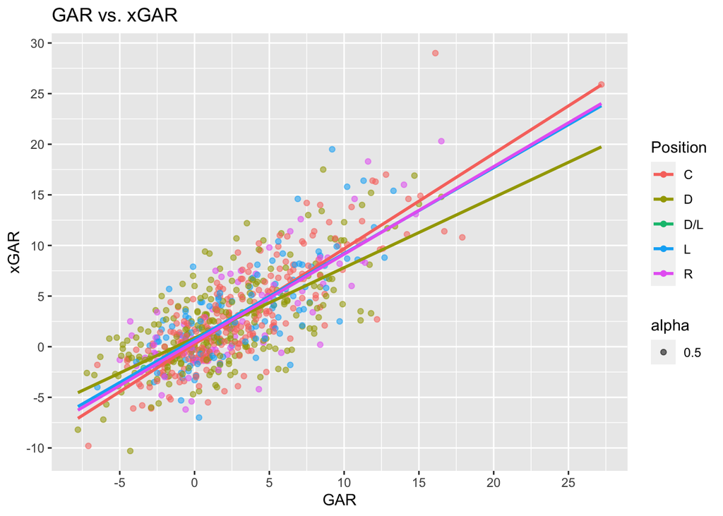

```r
ggplot(clean_data, aes(x=GAR, y=xGAR, color = Position)) +
  geom_point(aes(alpha=0.5)) + geom_smooth(method=lm, se=FALSE, fullrange=TRUE) + ggtitle("GAR vs. xGAR") + scale_y_continuous(breaks=c(-10,-5,0,5,10,15, 20, 25, 30, 35)) + scale_x_continuous(breaks=c(-10,-5,0,5,10,15, 20, 25, 30, 35))
```

This plot shows the actual GAR for every player that played over 200 minutes on the x-axis, and the expected GAR (xGAR) on the y-axis, grouped by position. For the most part, players of every position were clustered around the trendline y=x, meaning there isn’t a huge disparty between the actual GAR and the xGAR. While the forwards all had similar regression lines around y=x, defensemen generally had a higher GAR than xGAR, making the regression line flatter. One player that really stands out in this plot is Auston Matthews, who has a much higher xGAR than actual GAR. This could suggest that he was unlucky during the season and actually made all the plays that should have generated more goals above replacement. Meanwhile, Connor McDavid had the highest GAR in the league and generally performed as expected as well.

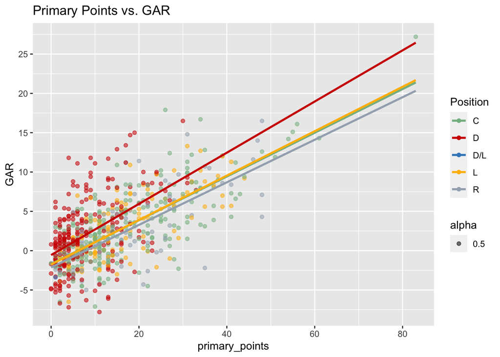

```r
ggplot(clean_data, aes(x=primary_points, y=GAR, color = Position)) +
  geom_point(aes(alpha=0.5)) + geom_smooth(method=lm, se=FALSE, fullrange=TRUE) + ggtitle("Primary Points vs. GAR") + scale_y_continuous(breaks=c(-10,-5,0,5,10,15, 20, 25, 30, 35)) + scale_x_continuous() + scale_color_manual(values=c("#86BA90", "#D00000", "#3F88C5", "#FFBA08", "#A2AEBB"))
```

This is a plot of primary points vs GAR, which can be interpreted as a player’s box score/scoreboard impact on the game vs. their more “unseen” impacts on the game. I chose to plot primary points instead of total points because primary points are more “valuable” even though all goals and assists are equivalent to one point. A primary point means that the player scored the goal or was the primary assist on a goal, and it excludes second assists. Connor McDavid once again stands out as far beyond the rest of the players in the league in terms of both primary points and GAR. An interesting observation here is that many defensemen who have few primary points actually have high GAR totals, which could suggest that points is not indicative of their actual impact of the game. This makes sense as defensemen contribute to the game outside of scoring points, as their primary job is not to score goals. Additionally, there are many forwards, specifically centers, who seem to be below the linear regression lines, suggesting that points are overexaggerating true their impact on the game and not accounting for things like defensive failures, which GAR does take into account.

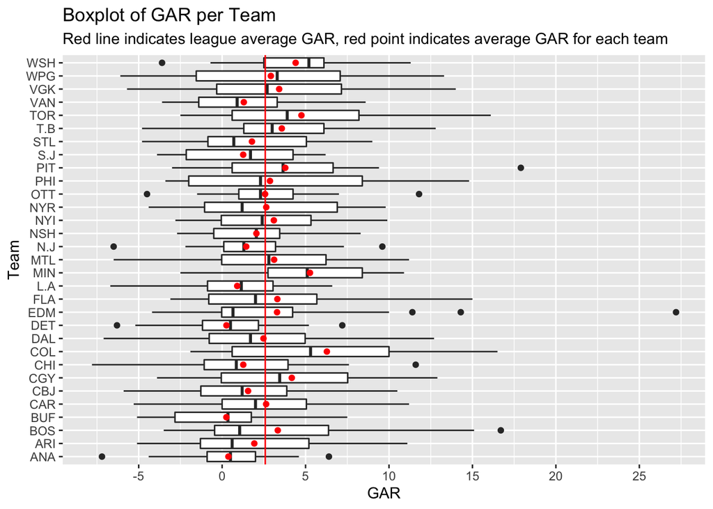

```r
mean_GAR <- clean_data %>% pull(GAR) %>% mean()
ggplot(clean_data, aes(x=Team, y=GAR)) +
    geom_boxplot() + stat_summary(fun.y=mean, geom="point", color="red", fill="red") + coord_flip() + geom_hline(yintercept = mean_GAR, color = "red", aes(alpha=0.5)) + ggtitle("Boxplot of GAR per Team", subtitle = "Red line indicates league average GAR, red point indicates average GAR for each team") + scale_y_continuous(breaks=c(-10,-5,0,5,10,15, 20, 25, 30, 35))
```

#### Concluding Remarks

In conclusion, there was a lot of data included with the CSVs that was interesting, and I did not get to explore the relationships between as many of them as I would have liked. However, I do think that it is worthwile to have investiagated the correlation or the lack of it between unseen contributions to the game (GAR/WAR/SPAR and the expected values of each) as well as the more commonly seen box scores. This project, even in its brevity, showed that there is often more than meets the eye and points alone should not be taken at face value, especially for players who may fly under the radar because of their position (defensemen specifically) or their point total.